# Difference or similarity between the scored TF in resident and exhausted cells

From scenic we have 2 set of scored TFs. Now to evaluate if they are indeed similar of different, I am going to do some exploratory analysis, then evaluate more robustly which is their similarity.

I will start with:

- plotting their distribution and the top enriched TFs
- Plot the overlap of 10% top eriched TF
- Evaluate scored TF between resident and exhausted NK cells using [Rank Biased Overlap (RBO)](https://dl.acm.org/doi/10.1145/1852102.1852106). This method seems adapt for this comparison because:
  - Can evaluate different sizes of ranked lists
  - It can assign weight to the n top ranks
  - provide a ration (or percentage) of similarity

Prepare environment

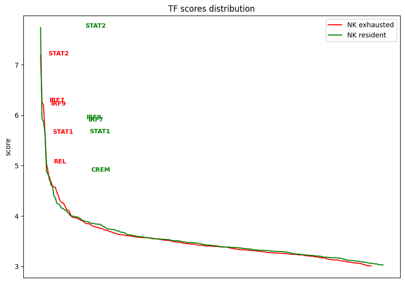

The distribution of (normalized) scores is quite similar, also of the top 5 scored TFs, 4 ae the same for both the conditions, let's check what they and their regulons are about:

### Phenotypes and Gene Ontology

```
interactive(children=(Dropdown(description='dataframe', options=('exh', 'res'), value='exh'), Select(descripti…
```

## Top 10% enriched TFs:

```
(23,)
```

```
(24,)
```

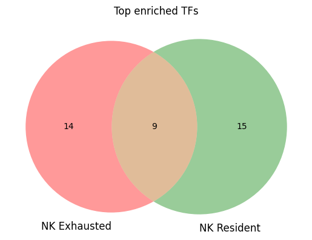

```
TF only in exhausted cells:
['FOXN2', 'ILF2', 'CEBPD', 'TBX21', 'CARF', 'SMAD3', 'NFIL3', 'JUNB', 'RUNX1', 'NFAT5', 'HTATIP2', 'IRF1', 'YY1', 'ZNF217']
TF only in resident:
['ING4', 'ZNF677', 'FOSB', 'ZNF441', 'CNOT3', 'ZBTB7A', 'GMEB2', 'ZNF134', 'MBD2', 'IRF2', 'ZNF146', 'CREM', 'ZNF669', 'BCLAF1', 'ZNF836']
TF shared:
['STAT2', 'NFKB1', 'IRF9', 'STAT1', 'ZBTB11', 'RELB', 'IRF7', 'NFKB2', 'REL']
```

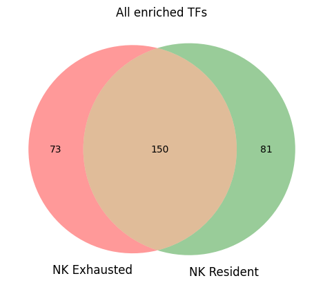

```
TF only in exhausted cells:
['ZNF581', 'ZNF737', 'FOXJ3', 'ZBTB33', 'ZNF564', 'ZNF148', 'SRF', 'ZNF641', 'ZNF518A', 'BCL11B', 'ZNF350', 'CERS4', 'HMG20B', 'GTF2B', 'TP53', 'ZNF92', 'ZNF250', 'ZFP90', 'FOXN2', 'ZNF25', 'ZNF286A', 'KLF6', 'CARF', 'RFX7', 'ZBTB43', 'PBX3', 'ELK1', 'ZBTB20', 'MBNL2', 'ZBTB4', 'TGIF1', 'NFAT5', 'NR…
TF only in resident:
['ZNF493', 'SOX4', 'RFXANK', 'TFDP2', 'ZNF429', 'ZNF639', 'ZNF383', 'CENPB', 'ZNF441', 'MXD1', 'HMGXB4', 'NR1H2', 'ZNF131', 'DPF2', 'STAT5A', 'ZNF37A', 'ZNF675', 'NFYC', 'HIF1A', 'RAD21', 'ZNF507', 'FOXP1', 'DRAP1', 'ZNF296', 'ZNF134', 'RFX1', 'ZFY', 'ATF5', 'KLF3', 'ZBTB24', 'TCF4', 'CNOT3', 'ZNF14…
TF shared:
['ATF1', 'EP300', 'USF1', 'BHLHE40', 'GABPA', 'RUNX1', 'FOXO1', 'JUN', 'ZFX', 'RXRB', 'SMAD3', 'ZEB1', 'JUNB', 'USF2', 'THRA', 'STAT6', 'YBX1', 'ATF4', 'ZNF217', 'ELF1', 'ESRRA', 'MBD2', 'ZNF333', 'ELF2', 'SMAD4', 'KMT2B', 'MAX', 'NR2C2', 'CEBPB', 'ETS1', 'ZNF267', 'HOXA10', 'IKZF2', 'ZNF384', 'NFAT…
```

## RBO

I plan to run the analysis in:

- all theranked TFs
- The top 10% enriched TF

Also, to polish the analisis I am going to tune the weight parameter in order to assign the appropriate weight to the top n TFs:

### All TFs

```
lenght lists are:
Exh:223	Res:231
D max:223
```

```
similarity considering ranks but without assigning weights to the top TFs:
0.65
```

Tuning the weight of the first 10 TFs:

```
value of P to assign 70% of the weight to the first 10 TFs id:
weight 0.7
p: 0.945
Similarity of all the enriched TFs assigning 70% of the score to the top 10:
0.59
```

```
value of P to assign 90% of the weight to the first 10 TFs id:
weight 0.9
p: 0.875
Similarity of all the enriched TFs assigning 90% of the score to the top 10:
0.73
```

Tuning the weight of the first 10% genes:

```
value of P to assign 90% of the weight to the first 10% TFs id:
weight 0.9
p: 0.943
Similarity of all the enriched TFs assigning 90% of the score to the top 10:
0.6
```

```
value of P to assign 70% of the weight to the first 10% TFs id:
weight 0.7
p: 0.976
Similarity of all the enriched TFs assigning 70% of the score to the top 10:
0.5
```

From the results observing all the TFs, we can draw the conclusion that giving most of the importance to the top 10 TFs, the similarity is quite high (0.73). Reducing the weight of the first TFs, or considering the first 10%, the similarity score get significantly reduced. Considering the cell groups are almost identical, I would expect a similari behaviour. Now focus on the top 10% eriched TFs:

### Top 10%

```
lenght lists are:
Exh:23	Res:24
D max:23
```

Tuning the weight for the first 25% TFs:

```
value of P to assign 90% of the weight to the first 25% TFs id:
weight 0.9
p: 0.795
Similarity of all the enriched TFs assigning 90% of the score to the top 25%:
0.79
```

```
value of P to assign 70% of the weight to the first 25% TFs id:
weight 0.7
p: 0.908
Similarity of all the enriched TFs assigning 70% of the score to the top 25%:
0.68
```

# Conclusions

The top 5 enriched TFs are similar. Of them:

- STAT1, STAT2, IRF7, IRF9, and their regulons are mainly involved in the response to immune stimulus (interferon, MHC, cytokine)
- REL in exhausted NK cell looks involved in reduced apoptosis
- CREM in resident NK cells looks more involved in mRNA regulation and ubiquitination